# Fluctuation and Dispersion analyses

Fred Hasselman & Maarten Wijnants

1/14/2018

# **Fluctuation and Disperion analyses**

### Three time series

We are going to analyse the same 3 time series as last session, now using fluctuation and dispersion analysis.

**Importing data**

Two ways:

A. By downloading:

1. Follow the link, e.g. for [`series.xlsx`](https://github.com/complexity-methods/CSA-assignments/blob/master/assignment_data/BasicTSA_arma/series.xlsx).
2. On the Github page, find a button marked **Download** (or **Raw** for text files).
3. Download the file
4. Load it into `R` using the code below

```r
library(rio)
series <- rio::import("series.xlsx")
```

B. By directly importing the file in R from Github:

1. Copy the `url` associated with the **Download** button [on Github](https://github.com/complexity-methods/CSA-assignments/blob/master/assignment_data/BasicTSA_arma/series.csv) (right-click).
2. The copied path should contain the word ‘raw’ somewhere in the url.
3. Call `rio::import(url)`

```r
library(rio)
series <- rio::import("https://github.com/complexity-methods/CSA-assignments/raw/master/assignment_data/BasicTSA_arma/series.xlsx")
```

### 2.0.1 Standardised Dispersion Analysis

#### Questions

- Common data preparation before running fluctuation analyses like `SDA`:
  - Normalize the time series (using `sd` based on `N`, not `N-1`, e.g. by using `ts_standardise()`, or use function arguments)
  - Check whether time series length is a power of `2`. If you use `N <- log2(length(y))`, the number you get is `2^N`. You need an integer power for the length in order to create equal bin sizes. You can pad the series with 0s, or make it shorter before analysis.
- Perform `sda` on the 3 time series, or any of the other series you already analysed.
- Compare to what you find for `fd_sda` to the other techniques (`fd_RR`,`SampEn`, `acf`, `pacf`)

#### Answers

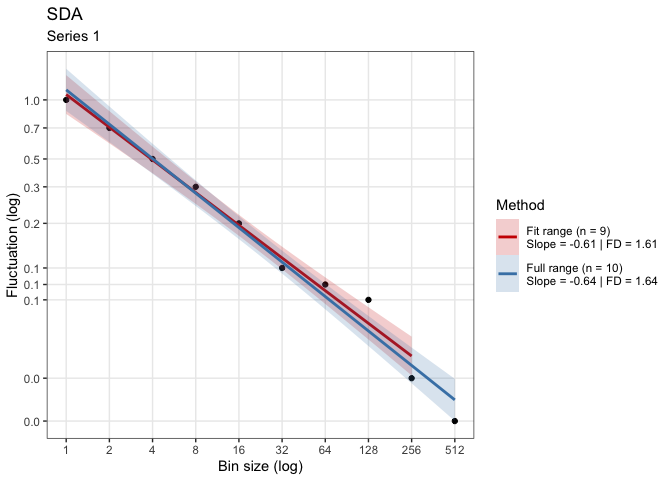

```r
library(casnet)

fdS1 <- fd_sda(series$TS_1, returnPLAW = TRUE)
##
##
## fd_sda:  Sample rate was set to 1.
##
##
## ~~~o~~o~~casnet~~o~~o~~~
##
##  Standardised Dispersion Analysis
##
##  Full range (n = 10)
## Slope = -0.64 | FD = 1.64
##
##  Fit range (n = 9)
## Slope = -0.61 | FD = 1.61
##
## ~~~o~~o~~casnet~~o~~o~~~
fdS2 <- fd_sda(series$TS_2, returnPLAW = TRUE)
##
##
## fd_sda:  Sample rate was set to 1.
##
##
## ~~~o~~o~~casnet~~o~~o~~~
##
##  Standardised Dispersion Analysis
##
##  Full range (n = 10)
## Slope = -0.58 | FD = 1.58
##
##  Fit range (n = 9)
## Slope = -0.55 | FD = 1.55
##
## ~~~o~~o~~casnet~~o~~o~~~
fdS3 <- fd_sda(series$TS_3, returnPLAW = TRUE)
##
##
## fd_sda:  Sample rate was set to 1.
##
##
## ~~~o~~o~~casnet~~o~~o~~~
##
##  Standardised Dispersion Analysis
##
##  Full range (n = 10)
## Slope = -0.64 | FD = 1.64
##
##  Fit range (n = 9)
## Slope = -0.58 | FD = 1.58
##
## ~~~o~~o~~casnet~~o~~o~~~

# If you asked to return the powerlaw (returnPLAW = TRUE) the function plotFD_loglog() can make a plot
plotFD_loglog(fdS1,title = "SDA", subtitle = "Series 1")
```

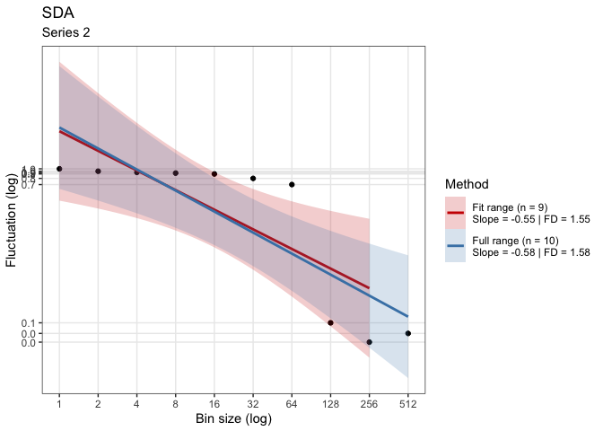

```r
plotFD_loglog(fdS2,title = "SDA", subtitle = "Series 2")
```

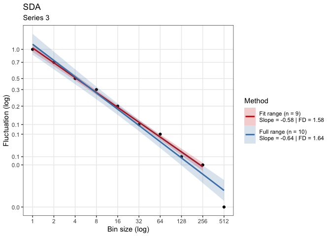

```r
plotFD_loglog(fdS3,title = "SDA", subtitle = "Series 3")
```